# titanic Logistic Regression

```python
import pandas as pd
import seaborn as sns
import numpy as np
import matplotlib.pyplot as plt
import scipy as sp
import sklearn as skl
import statsmodels as sm
import statsmodels.formula.api as smf
from statsmodels.tools import add_constant
from sklearn.experimental import enable_iterative_imputer
from sklearn.impute import IterativeImputer
from statsmodels.stats.outliers_influence import variance_inflation_factor
from sklearn.metrics import roc_curve, roc_auc_score, root_mean_squared_error
from sklearn.model_selection import cross_val_predict
from sklearn.metrics import precision_recall_curve
from sklearn.model_selection import StratifiedKFold
from scipy.stats import kstest
from dython.nominal import associations
import warnings
warnings.simplefilter(action='ignore', category=FutureWarning)
```

```python
gen_sub = pd.read_csv('gender_submission.csv')
data_train = pd.read_csv('train.csv')
data_test = pd.read_csv('test.csv')
data_train.head()
```

|  | PassengerId | Survived | Pclass | Name | Sex | Age | SibSp | Parch | Ticket | Fare | Cabin | Embarked |
| --- | --- | --- | --- | --- | --- | --- | --- | --- | --- | --- | --- | --- |
| 0 | 1 | 0 | 3 | Braund, Mr. Owen Harris | male | 22.0 | 1 | 0 | A/5 21171 | 7.2500 | NaN | S |
| 1 | 2 | 1 | 1 | Cumings, Mrs. John Bradley (Florence Briggs Th... | female | 38.0 | 1 | 0 | PC 17599 | 71.2833 | C85 | C |
| 2 | 3 | 1 | 3 | Heikkinen, Miss. Laina | female | 26.0 | 0 | 0 | STON/O2. 3101282 | 7.9250 | NaN | S |
| 3 | 4 | 1 | 1 | Futrelle, Mrs. Jacques Heath (Lily May Peel) | female | 35.0 | 1 | 0 | 113803 | 53.1000 | C123 | S |
| 4 | 5 | 0 | 3 | Allen, Mr. William Henry | male | 35.0 | 0 | 0 | 373450 | 8.0500 | NaN | S |

```python
data_test.head()
```

|  | PassengerId | Pclass | Name | Sex | Age | SibSp | Parch | Ticket | Fare | Cabin | Embarked |
| --- | --- | --- | --- | --- | --- | --- | --- | --- | --- | --- | --- |
| 0 | 892 | 3 | Kelly, Mr. James | male | 34.5 | 0 | 0 | 330911 | 7.8292 | NaN | Q |
| 1 | 893 | 3 | Wilkes, Mrs. James (Ellen Needs) | female | 47.0 | 1 | 0 | 363272 | 7.0000 | NaN | S |
| 2 | 894 | 2 | Myles, Mr. Thomas Francis | male | 62.0 | 0 | 0 | 240276 | 9.6875 | NaN | Q |
| 3 | 895 | 3 | Wirz, Mr. Albert | male | 27.0 | 0 | 0 | 315154 | 8.6625 | NaN | S |
| 4 | 896 | 3 | Hirvonen, Mrs. Alexander (Helga E Lindqvist) | female | 22.0 | 1 | 1 | 3101298 | 12.2875 | NaN | S |

# Removendo variáveis irrelevantes

As variáveis "Name", "Ticket" e "Cabin" não serão úteis para a nossa análise.

```python
# removendo variáveis inúteis
data_train = data_train.drop(['Name', 'Ticket', 'Cabin'], axis = 1)
data_test = data_test.drop(['Name', 'Ticket', 'Cabin'], axis = 1)
# concatenando os dois bancos
data = pd.concat([data_train, data_test]).reset_index(drop = True)
data = pd.merge(data, gen_sub, on = 'PassengerId', how = 'outer')
data['Survived'] = data['Survived_x'].combine_first(data['Survived_y'])
data.drop(columns=['Survived_x', 'Survived_y'], inplace=True)
data['Survived'] = data['Survived'].astype(int)
data
```

|  | PassengerId | Pclass | Sex | Age | SibSp | Parch | Fare | Embarked | Survived |
| --- | --- | --- | --- | --- | --- | --- | --- | --- | --- |
| 0 | 1 | 3 | male | 22.0 | 1 | 0 | 7.2500 | S | 0 |
| 1 | 2 | 1 | female | 38.0 | 1 | 0 | 71.2833 | C | 1 |
| 2 | 3 | 3 | female | 26.0 | 0 | 0 | 7.9250 | S | 1 |
| 3 | 4 | 1 | female | 35.0 | 1 | 0 | 53.1000 | S | 1 |
| 4 | 5 | 3 | male | 35.0 | 0 | 0 | 8.0500 | S | 0 |
| ... | ... | ... | ... | ... | ... | ... | ... | ... | ... |
| 1304 | 1305 | 3 | male | NaN | 0 | 0 | 8.0500 | S | 0 |
| 1305 | 1306 | 1 | female | 39.0 | 0 | 0 | 108.9000 | C | 1 |
| 1306 | 1307 | 3 | male | 38.5 | 0 | 0 | 7.2500 | S | 0 |
| 1307 | 1308 | 3 | male | NaN | 0 | 0 | 8.0500 | S | 0 |
| 1308 | 1309 | 3 | male | NaN | 1 | 1 | 22.3583 | C | 0 |

1309 rows × 9 columns

# Análise exploratória

Vamos analisar as distribuições das variáveis na amostra bem como as distribuições delas em cada nível de Survived. Analisar separadamente em cada grupo que sobreviveu ou não é importante para encontrarmos possíveis pistas e padrões em cada grupo.

## Survived

A variável Survived indica se a pessoa faleceu à bordo do Titanic. Ela é a nossa variável resposta.

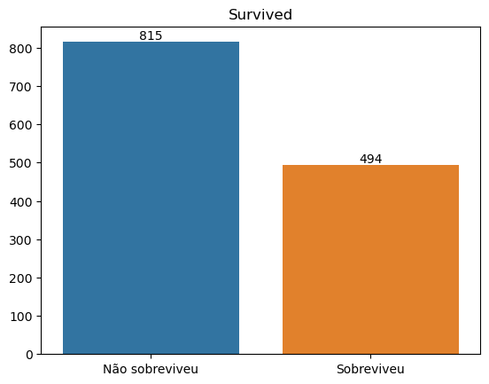

```python
ax = sns.countplot(x = data['Survived'], hue = data['Survived'])
ax.set_xlabel('')
ax.set_ylabel('')
ax.set_title('Survived')
ax.set_xticks([0, 1], labels = ['Não sobreviveu', 'Sobreviveu'])
ax.legend().remove()
for container in ax.containers:
    ax.bar_label(container)
```

Podemos notar que há um desbalanço na variável em favor do nível que representam as pessoas que não sobreviveram, que representam aproximadamente 62.26% do total. Apenas 37.74% das pessoas sobreviveram ao acidente.

## Age

A variável Age representa a idade em anos das pessoas à bordo do Titanic.

```
<function matplotlib.pyplot.tight_layout(*, pad: 'float' = 1.08, h_pad: 'float | None' = None, w_pad: 'float | None' = None, rect: 'tuple[float, float, float, float] | None' = None) -> 'None'>
```

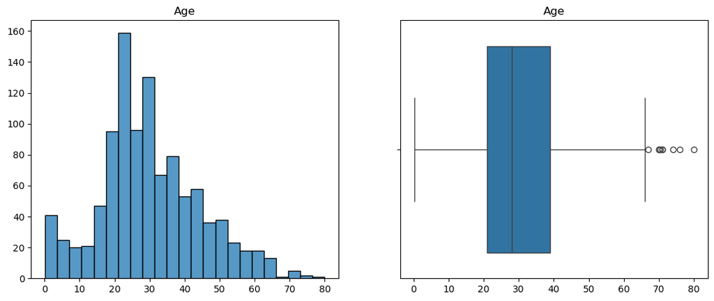

```python
fig, ax = plt.subplots(1, 2, figsize = (13, 5))
ax = ax.flatten()
ax[0] = sns.histplot(x = data['Age'], ax = ax[0])
ax[0].set_xlabel('')
ax[0].set_ylabel('')
ax[0].set_title('Age')

ax[1] = sns.boxplot(x = data['Age'])
ax[1].set_xlabel('')
ax[1].set_title('Age')

plt.tight_layout
```

```python
print('IIQ = [', data['Age'].quantile(0.25), ', ', data['Age'].quantile(0.75), '].')
```

```
IIQ = [ 21.0 ,  39.0 ].
```

ou seja, as pessoas que correspondem aos 50% centrais têm entre 21 e 39 anos. Com isto é possível perceber que as pessoas à bordo do Titanic eram jovens.

### Age por nível de Survived

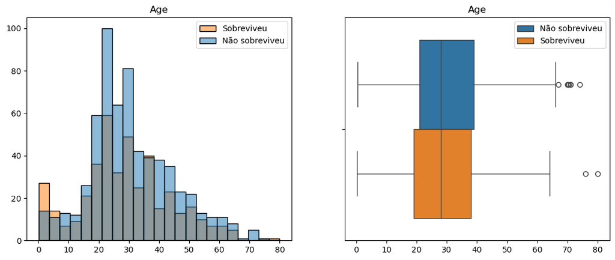

```python
fig, ax = plt.subplots(1, 2, figsize = (13, 5))
ax = ax.flatten()
ax[0] = sns.histplot(x = data['Age'], hue = data['Survived'], ax = ax[0])
ax[0].set_xlabel('')
ax[0].set_ylabel('')
ax[0].set_title('Age')
ax[0].legend(['Sobreviveu', 'Não sobreviveu'])

ax[1] = sns.boxplot(x = data['Age'], hue = data['Survived'])
ax[1].set_xlabel('')
ax[1].set_title('Age')
ax[1].legend(['Não sobreviveu', 'Sobreviveu'])

plt.tight_layout
plt.show()
```

Podemos perceber que a distribuição dos dados de Age em cada nível de Survived são parecidas. Os intervalos interquartílicos são os seguintes:

```python
AgeSurv0 = data['Age'][data['Survived'] == 0]
AgeSurv1 = data['Age'][data['Survived'] == 1]
print('IIQ de Age que não sobreviveram = [', AgeSurv0.quantile(0.25), ', ', AgeSurv0.quantile(0.75), '].')
print('IIQ de Age que sobreviveram = [', AgeSurv1.quantile(0.25), ', ', AgeSurv1.quantile(0.75), '].')
```

```
IIQ de Age que não sobreviveram = [ 21.0 ,  39.0 ].
IIQ de Age que sobreviveram = [ 19.0 ,  38.0 ].
```

Os IIQs são bem parecidos, a maior diferença entre eles está do quartil 1. Nas duas distribuições também há alguns outliers, entre os que não sobreviveram há mais do que entre os que sobreviveram.

## Pclass

A variável Pclass indica a qual classe o ticket daquela pessoa observada pertence. Seus possíveis valores são 1 = 1ª classe, 2 = 2ª classe, 3 = 3ª classe.

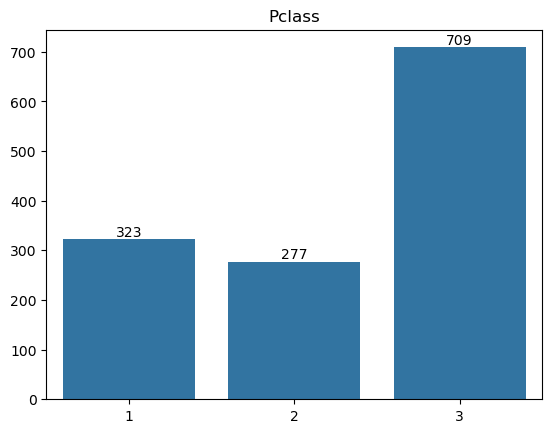

```python
ax = sns.countplot(x = data['Pclass'])
ax.set_title('Pclass')
ax.set_xlabel('')
ax.set_ylabel('')
for container in ax.containers:
    ax.bar_label(container)
```

Podemos notar que há muito mais pessoas na terceira classe do que nas outras. Aproximadamente 54.16% dos passageiros estão nesta classe, enquanto que 24.68% e 21.16% estão na primeira e segunda classes, respectivamente.

### Pclass por nível de Survived

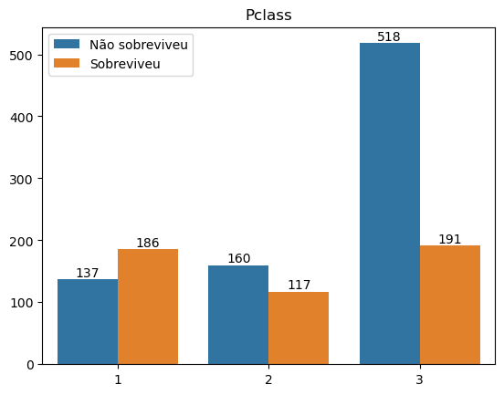

```python
ax = sns.countplot(x = data['Pclass'], hue = data['Survived'])
ax.set_title('Pclass')
ax.set_xlabel('')
ax.set_ylabel('')
ax.legend(['Não sobreviveu', 'Sobreviveu'])
for container in ax.containers:
    ax.bar_label(container)
```

Há um desbalanço entre a quantidade de pessoas que sobreviveram e as que não sobreviveram na 3ª classe. Aproximadamente 73.06% das pessoas que estavam na 3ª classe não sobreviveram ao acidente, enquanto que nas primeira e segunda classes aproximadamente 42.41% e 57.76%, respectivamente, não sobreviveram.

## Sex

Esta variável indica o gênero das pessoas à bordo do Titanic.

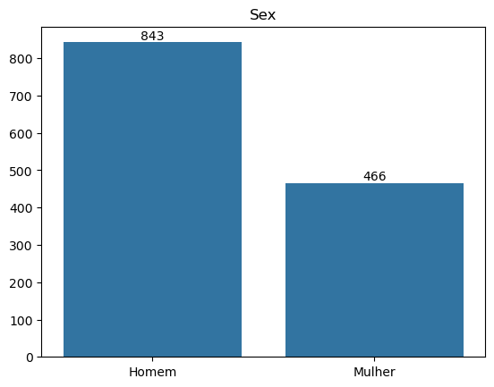

```python
ax = sns.countplot(x = data['Sex'])
ax.set_title('Sex')
ax.set_xlabel('')
ax.set_ylabel('')
ax.set_xticks([0, 1], ['Homem', 'Mulher'])
for container in ax.containers:
    ax.bar_label(container)
```

Há um desbalanço entre os níveis da variável Sex. Aproximadamente 64.4% das observações são do gênero masculino e 35.6% do gênero feminino.

### Sex por nível de Survived

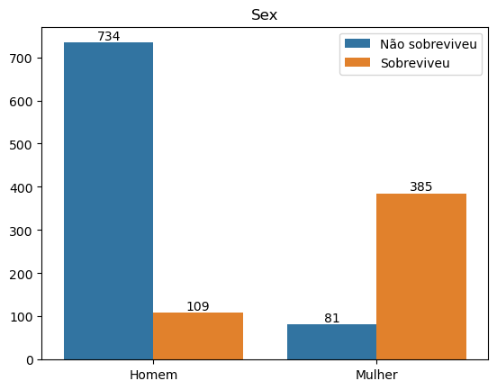

```python
ax = sns.countplot(x = data['Sex'], hue = data['Survived'])
ax.set_title('Sex')
ax.set_xlabel('')
ax.set_ylabel('')
ax.set_xticks([0, 1], ['Homem', 'Mulher'])
ax.legend(['Não sobreviveu', 'Sobreviveu'])
for container in ax.containers:
    ax.bar_label(container)
```

Um enorme desbalanço entre os homens quando falamos da sobrevivência ao acidente do Titanic. Aproximadamente 87.07% dos homens não sobreviveram, enquanto que aproximadamente 17.38% das mulheres não sobreviveram.

## SibSp

Esta variável indica o número de irmãos e cônjuges à bordo.

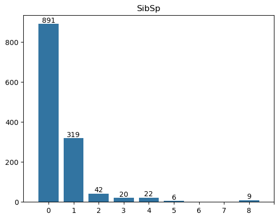

```python
counts = data['SibSp'].value_counts().sort_index()
counts[6] = 0
counts[7] = 0
counts = counts.sort_index()
ax = sns.barplot(x = counts.index, y = counts.values)
ax.set_title('SibSp')
ax.set_xlabel('')
ax.set_ylabel('')
plt.xlim(-1, 9)
ax.set_xticks(range(0,10))
for bar, value in zip(ax.patches, counts.values):
    if value > 0:
        ax.text(
            bar.get_x() + bar.get_width() / 2,
            bar.get_height(),
            str(value),
            ha = 'center',
            va = 'bottom'
        )
plt.show()
```

### SibSp por nível de Survived

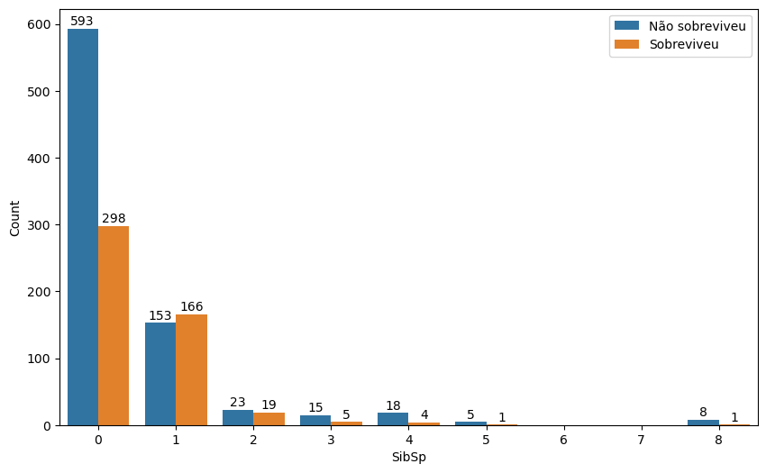

```python
sibsp_range = range(0, 9)
surv_categories = data['Survived'].unique()

full_index = pd.MultiIndex.from_product([sibsp_range, surv_categories], names = ['SibSp', 'Survived'])
counts = data.groupby(['SibSp', 'Survived']).size().reindex(full_index, fill_value = 0).reset_index(name = 'Count')
fig, ax = plt.subplots(figsize=(10,6))
ax = sns.barplot(data = counts, x = 'SibSp', y = 'Count', hue = 'Survived')
handles, labels = ax.get_legend_handles_labels()
ax.legend(handles = handles, labels = ['Não sobreviveu', 'Sobreviveu'])
for bar in plt.gca().patches:
    height = bar.get_height()
    if height > 0:
        plt.gca().text(
            bar.get_x() + bar.get_width() / 2,
            height + 1,
            int(height),
            ha='center',
            va='bottom'
        )
plt.show()
```

Entre as pessoas com nenhum irmão/cônjuge à bordo, aproximadamente 66.55% delas não sobreviveram ao acidente.

## Parch

Esta variável indica o número de pais e filhos correspondente à pessoa.

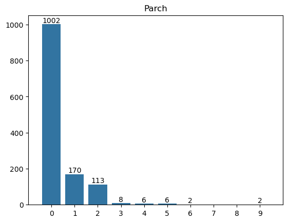

```python
counts = data['Parch'].value_counts().sort_index()
counts[7] = 0
counts[8] = 0
counts = counts.sort_index()
ax = sns.barplot(x = counts.index, y = counts.values)
ax.set_title('Parch')
ax.set_xlabel('')
ax.set_ylabel('')
plt.xlim(-1, 10)
ax.set_xticks(range(0,10))
for bar, value in zip(ax.patches, counts.values):
    if value > 0:
        ax.text(
            bar.get_x() + bar.get_width() / 2,
            bar.get_height(),
            str(value),
            ha = 'center',
            va = 'bottom'
        )
plt.show()
```

A grande maioria de pessoas estava com nenhum pai/filho à bordo, cerca de 76.54% do total.

### Parch por nível de Survived

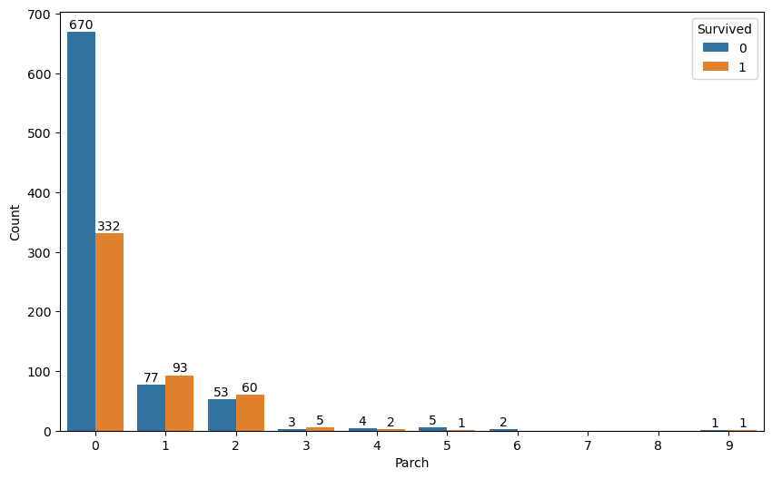

```python
parch_range = range(0, 10)
surv_categories = data['Survived'].unique()

full_index = pd.MultiIndex.from_product([parch_range, surv_categories], names = ['Parch', 'Survived'])
counts = data.groupby(['Parch', 'Survived']).size().reindex(full_index, fill_value = 0).reset_index(name = 'Count')
fig, ax = plt.subplots(figsize=(10,6))
ax = sns.barplot(data = counts, x = 'Parch', y = 'Count', hue = 'Survived')

for bar in plt.gca().patches:
    height = bar.get_height()
    if height > 0:
        plt.gca().text(
            bar.get_x() + bar.get_width() / 2,
            height + 1,
            int(height),
            ha='center',
            va='bottom'
        )

plt.show()
```

Entre as 1002 pessoas com nenhum pai/filho à bordo, 66.87% não sobreviveram.

Entre as 170 pessoas que tinham 1 pai/filho à bordo, aproximadamente 45.29% não sobreviveram.

Entre as 113 pessoas que tinham 2 pais/filhos à bordo, 46.9% não sobreviveram.

Entre as 8 pessoas que tinham 3 pais/filhos à bordo, aproximadamente 37.5% não sobreviveram.

Entre as 6 pessoas que tinham 4 pais/filhos à bordo, aproximadamente 66.7% não sobreviveram.

Entre as 6 pessoas que tinham 5 pais/filhos à bordo, aproximadamente 83.3% não sobreviveram.

As duas pessoas que tinham 6 pais/filhos à bordo não sobreviveram ao acidente.

Uma das duas pessoas que tinha 9 filhos/pais à bordo não sobreviveram ao acidente.

## Fare

Esta variável indica o valor da tarifa paga pela pessoa.

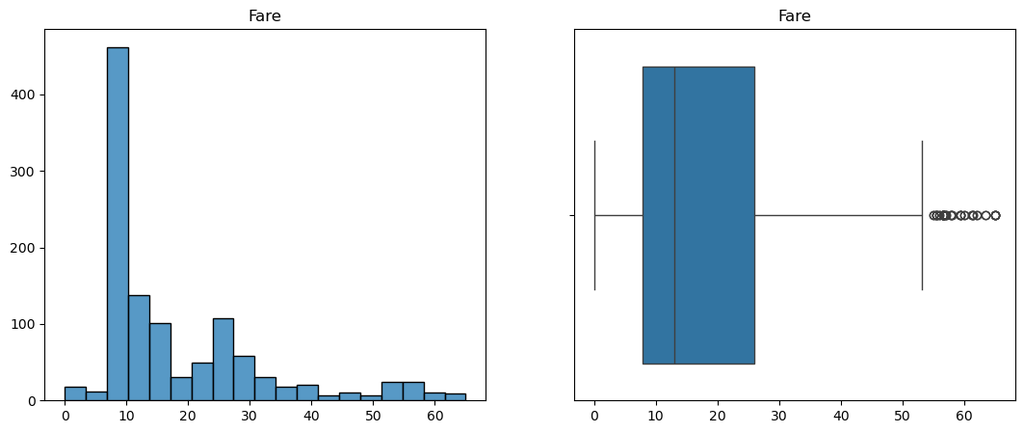

```python
def outliers(data):
    Q1 = data.quantile(0.25)
    Q3 = data.quantile(0.75)
    IIQ = Q3 - Q1
    lower_bound = Q1 - 1.5*IIQ
    upper_bound = Q3 + 1.5*IIQ
    no_outlier = data[(data > lower_bound) & (data < upper_bound)]
    return no_outlier

Fare_no_outlier = outliers(data['Fare'])
fig, ax = plt.subplots(1, 2, figsize = (13, 5))
ax = ax.flatten()
ax[0] = sns.histplot(x = Fare_no_outlier, ax = ax[0])
ax[0].set_xlabel('')
ax[0].set_ylabel('')
ax[0].set_title('Fare')

ax[1] = sns.boxplot(x = Fare_no_outlier)
ax[1].set_xlabel('')
ax[1].set_title('Fare')

plt.tight_layout
plt.show()
```

Como há muitos outliers, precisamos remover os que se distanciavam muito do restante dos dados. O critério de exclusão dos outliers foi para os que estão 1.5*IIQ abaixo do quartil 1 e 1.5*IIQ acima do quartil 3.

Podemos notar uma assimetria à direita bastante proeminente e uma curtose que deixa a distribuição com característica leptocúrtica. O intervalo interquartílico é igual a

```python
print('IIQ = [', data['Fare'].quantile(0.25), ', ', data['Fare'].quantile(0.75), '].')
```

```
IIQ = [ 7.8958 ,  31.275 ].
```

Ou seja, os dados centrais correspondentes à 50% das observações estão entre 7.8958 e 31.275.

### Fare por nível de Survived

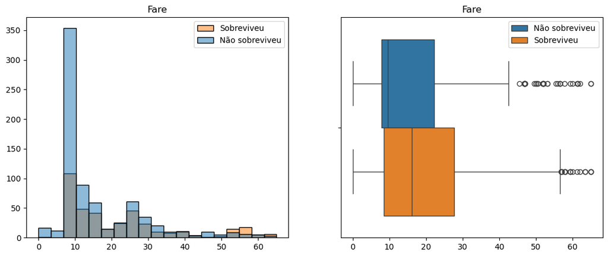

```python
fig, ax = plt.subplots(1, 2, figsize = (13, 5))
ax = ax.flatten()
ax[0] = sns.histplot(x = Fare_no_outlier, hue = data['Survived'], ax = ax[0])
ax[0].set_xlabel('')
ax[0].set_ylabel('')
ax[0].set_title('Fare')
ax[0].legend(['Sobreviveu', 'Não sobreviveu'])

ax[1] = sns.boxplot(x = Fare_no_outlier, hue = data['Survived'])
ax[1].set_xlabel('')
ax[1].set_title('Fare')
ax[1].legend(['Não sobreviveu', 'Sobreviveu'])

plt.tight_layout
plt.show()
```

A distribuição dos dados de Fare entre as pessoas que sobreviveram e as que não sobreviveram. Muitas pessoas que pagaram pouco morreram.

## Embarked

Esta variável indica o local de embarque (C = Cherbourg, Q = Queenstown, S = Southampton).

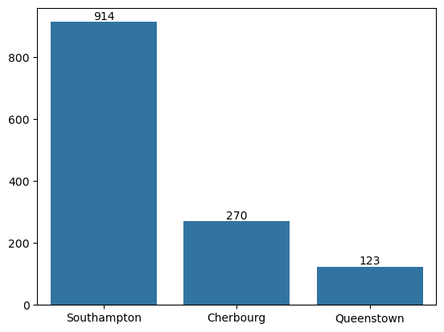

```python
ax = sns.countplot(x = data['Embarked'])
ax.set_xticks([0, 1, 2], ['Southampton', 'Cherbourg', 'Queenstown'])
ax.set_ylabel('')
ax.set_xlabel('')
for container in ax.containers:
    ax.bar_label(container)
```

Cerca de 69.82% das pessoas no Titanic embarcaram em Southampton, no Reino Unido. Aproximadamente 20.62% das pessoas embarcaram em Cherbourg, na França. Por fim, 9.4% das pessoas à bordo do Titanic embarcaram em Queenstown, na Nova Zelândia.

### Embarked por nível de Survived

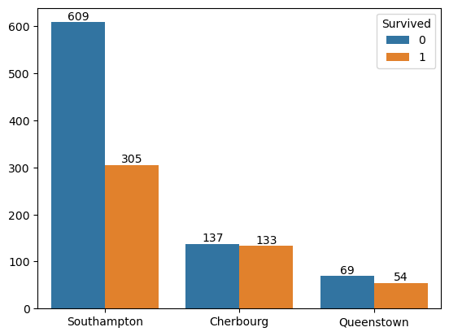

```python
ax = sns.countplot(x = data['Embarked'], hue = data['Survived'])
ax.set_xticks([0, 1, 2], ['Southampton', 'Cherbourg', 'Queenstown'])
ax.set_ylabel('')
ax.set_xlabel('')
for container in ax.containers:
    ax.bar_label(container)
```

Há uma diferença grande entre a quantidade relativa de pessoas que não sobreviveram ao acidente quando embarcadas em diferentes localidades. Aproximadamente 66.63% das pessoas que embarcaram em Southampton não sobreviveram ao acidente. Entre as pessoas que embarcaram em Cherbourg, aproximadamente 50.7% delas não sobreviveram ao acidente. Já para as pessoas que embarcaram em Queenstown a taxa de não sobrevivência é cerca de 56,1% nesta amostra.

## Matriz de correlações

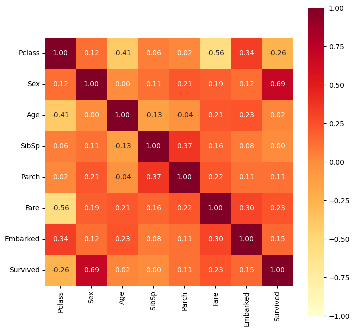

```python
corr = associations(
    data.drop(columns = ['PassengerId'], axis = 1),
    nominal_columns = 'auto',   # detecta colunas categóricas
    numerical_columns = 'auto',    # detecta colunas numéricas
    figsize = (8, 8),
    cmap = 'YlOrRd'
)
```

Em geral as correlações são fracas entre as variáveis, existem algumas exceções, como Sex versus Survived, com 0.69; Pclass versus Fare, com 0.6; e Pclass versus Age, com 0.41.

Esta matriz de correlações foi calculada usando coeficiente de correlação de Pearson para correlações entre duas variáveis númericas, correlation ratio para correlações entre variáveis categóricas e numéricas, e medida V de Cramér para correlações entre variáveis categóricas.

# Imputação de valores faltantes

```python
data.isna().sum() # 263 NAs em Age
                  # 1 NA em Fare
                  # 2 NAs em Embarked
```

```
PassengerId      0
Pclass           0
Sex              0
Age            263
SibSp            0
Parch            0
Fare             1
Embarked         2
Survived         0
dtype: int64
```

Temos alguns dados faltantes: 263 na variável "Age", 1 na variável "Fare" e 2 na variável "Embarked".

```python
data.duplicated().astype(int).sum() # nenhuma linha duplicada
```

```
0
```

## Imputação da variável Embarked

Como Embarked é uma variável categórica, vamos imputar com a moda.

```python
data['Embarked'].value_counts()
```

```
Embarked
S    914
C    270
Q    123
Name: count, dtype: int64
```

```python
data['Embarked'] = data['Embarked'].fillna('S')
```

```python
data.isna().sum()
```

```
PassengerId      0
Pclass           0
Sex              0
Age            263
SibSp            0
Parch            0
Fare             1
Embarked         0
Survived         0
dtype: int64
```

## Imputação da variável Age

Como a variável Age é contínua vamos analisar se podemos imputar a mediana. Iremos verificar a distribuição dos dados para cada categoria da variável Sex sem os outliers. Caso as distribuições de Age em cada categoria de Sex forem diferentes, não podemos imputar com a mediana.

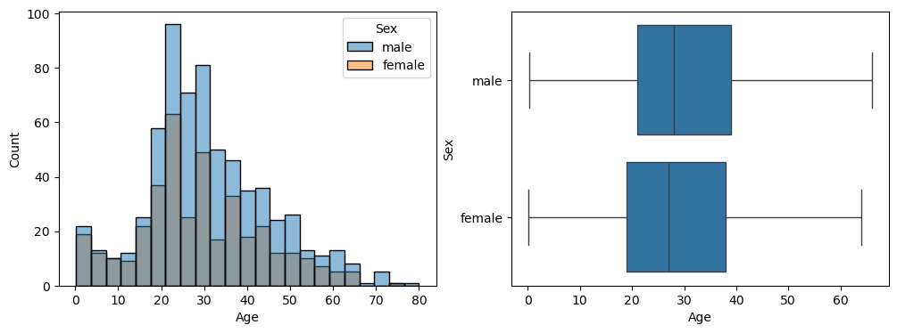

```
median global age =  28.0
```

```python
# verificando a distribuição dos dados de Age para as categorias de Sex
fig, (ax1, ax2) = plt.subplots(1, 2, figsize = (12,4))
sns.histplot(x = 'Age', hue = 'Sex', data = data, ax = ax1)
sns.boxplot(x = 'Age', y = 'Sex', data = data, ax = ax2, showfliers = False)
plt.show()
# aparentemente tem a mesma distribuição, então imputar a mediana não vai comprometer os dados
print('median global age = ', data['Age'].median())
```

```python
AgeMale = data['Age'][data['Sex'] == 'male'].dropna()
AgeFemale = data['Age'][data['Sex'] == 'female'].dropna()
kstest(AgeMale, AgeFemale).pvalue
```

```
0.056346439588368526
```

O teste Kolmogorov-Smirnov de duas amostras não encontrou evidências para afirmarmos que as distribuições são diferentes.

```python
data['Age'] = data['Age'].fillna(data['Age'].median())
data.isna().sum()
```

```
PassengerId    0
Pclass         0
Sex            0
Age            0
SibSp          0
Parch          0
Fare           1
Embarked       0
Survived       0
dtype: int64
```

## Imputação da variável Fare

Faremos o mesmo que fizemos na variável Age, na variável Fare.

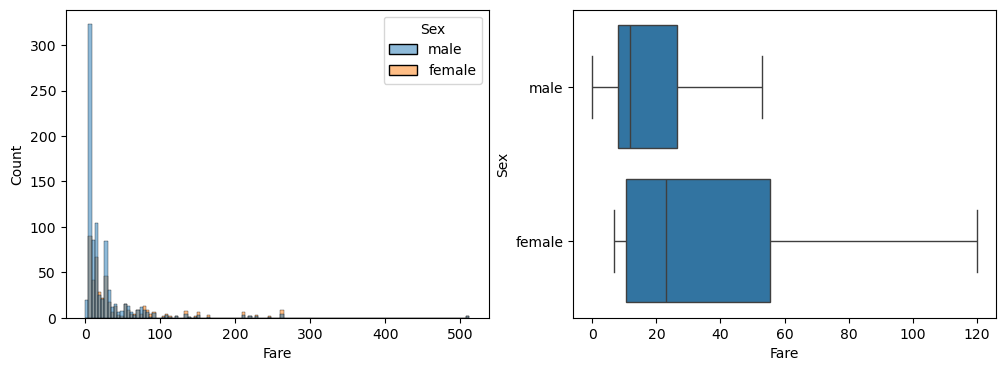

```python
# verificando a distribuição dos dados de Fare para as categorias de Sex
fig, (ax1, ax2) = plt.subplots(1, 2, figsize = (12,4))
sns.histplot(x = 'Fare', hue = 'Sex', data = data, ax = ax1)
sns.boxplot(x = 'Fare', y = 'Sex', data = data, ax = ax2, showfliers = False)
```

```python
FareMale = data['Fare'][data['Sex'] == 'male'].dropna()
FareFemale = data['Fare'][data['Sex'] == 'female'].dropna()
kstest(FareMale, FareFemale).pvalue
```

```
7.421785903652769e-16
```

O teste de Kolmogorov-Smirnov para duas amostras encontrou evidências para afirmarmos que as distribuições de Fare para cada nível de Sex são diferentes. Vamos utilizar MICE para imputar na observação faltante já que não há problemas em usar.

Antes de utilizarmos o MICE precisamos remover as variáveis que não podemos usar (PassengerId, pois é somente um índice; e Survived, pois é nossa variável resposta, logo comprometeria nosso modelo preditivo) e colocar as variáveis categóricas (Sex, Pclass e Embarked) como dummies.

```python
# imputando para Fare usando MICE
x = data.drop(['PassengerId', 'Survived'], axis = 1)
x = pd.get_dummies(x, columns = ['Sex', 'Pclass', 'Embarked'], drop_first = True)
imp = IterativeImputer(random_state = 28051996)
imputed = imp.fit_transform(x)
data_imputed = pd.DataFrame(imputed, columns=x.columns)
data_imputed = pd.concat([data[['PassengerId', 'Survived']], data_imputed], axis = 1)
data_imputed
```

|  | PassengerId | Survived | Age | SibSp | Parch | Fare | Sex_male | Pclass_2 | Pclass_3 | Embarked_Q | Embarked_S |
| --- | --- | --- | --- | --- | --- | --- | --- | --- | --- | --- | --- |
| 0 | 1 | 0 | 22.0 | 1.0 | 0.0 | 7.2500 | 1.0 | 0.0 | 1.0 | 0.0 | 1.0 |
| 1 | 2 | 1 | 38.0 | 1.0 | 0.0 | 71.2833 | 0.0 | 0.0 | 0.0 | 0.0 | 0.0 |
| 2 | 3 | 1 | 26.0 | 0.0 | 0.0 | 7.9250 | 0.0 | 0.0 | 1.0 | 0.0 | 1.0 |
| 3 | 4 | 1 | 35.0 | 1.0 | 0.0 | 53.1000 | 0.0 | 0.0 | 0.0 | 0.0 | 1.0 |
| 4 | 5 | 0 | 35.0 | 0.0 | 0.0 | 8.0500 | 1.0 | 0.0 | 1.0 | 0.0 | 1.0 |
| ... | ... | ... | ... | ... | ... | ... | ... | ... | ... | ... | ... |
| 1304 | 1305 | 0 | 28.0 | 0.0 | 0.0 | 8.0500 | 1.0 | 0.0 | 1.0 | 0.0 | 1.0 |
| 1305 | 1306 | 1 | 39.0 | 0.0 | 0.0 | 108.9000 | 0.0 | 0.0 | 0.0 | 0.0 | 0.0 |
| 1306 | 1307 | 0 | 38.5 | 0.0 | 0.0 | 7.2500 | 1.0 | 0.0 | 1.0 | 0.0 | 1.0 |
| 1307 | 1308 | 0 | 28.0 | 0.0 | 0.0 | 8.0500 | 1.0 | 0.0 | 1.0 | 0.0 | 1.0 |
| 1308 | 1309 | 0 | 28.0 | 1.0 | 1.0 | 22.3583 | 1.0 | 0.0 | 1.0 | 0.0 | 0.0 |

1309 rows × 11 columns

```python
data_imputed.isna().sum() # nenhum dado faltante
```

```
PassengerId    0
Survived       0
Age            0
SibSp          0
Parch          0
Fare           0
Sex_male       0
Pclass_2       0
Pclass_3       0
Embarked_Q     0
Embarked_S     0
dtype: int64
```

```python
# refazendo as bases de treino e de teste
data_train = data_imputed.iloc[0:891]
data_test = data_imputed.iloc[891:]
```

# Modelo preditivo usando regressão logística

## Verificação de multicolinearidade

Vamos usar o Variance Inflation Factor para medir a multicolinearidade entre as variáveis do modelo.

```python
# regressão logística
x = data_train.drop('Survived', axis = 1)
x = add_constant(x)
y = data_train['Survived']
vif = pd.DataFrame()
vif["Variável"] = x.columns
vif["VIF"] = [variance_inflation_factor(x.values, i) for i in range(x.shape[1])]
vif
```

|  | Variável | VIF |
| --- | --- | --- |
| 0 | const | 26.988491 |
| 1 | PassengerId | 1.008011 |
| 2 | Age | 1.224076 |
| 3 | SibSp | 1.289590 |
| 4 | Parch | 1.334924 |
| 5 | Fare | 1.765767 |
| 6 | Sex_male | 1.133313 |
| 7 | Pclass_2 | 2.079747 |
| 8 | Pclass_3 | 2.767721 |
| 9 | Embarked_Q | 1.493583 |
| 10 | Embarked_S | 1.501090 |

Podemos verificar que não há multicolinearidade forte entre as variáveis. Portanto, podemos seguir com a implementação do modelo

## Definição do modelo

```python
formula = 'y ~ Age + SibSp + Parch + Fare + Sex_male + Pclass_2 + Pclass_2  + Embarked_Q + Embarked_S'
SurvModel = smf.logit(formula, data = data_train)
SurvFit = SurvModel.fit()
SurvFit.summary()
```

```
Optimization terminated successfully.
         Current function value: 0.468969
         Iterations 6
```

Logit Regression Results

| Dep. Variable: | y | No. Observations: | 891 |
| --- | --- | --- | --- |
| Model: | Logit | Df Residuals: | 882 |
| Method: | MLE | Df Model: | 8 |
| Date: | Sat, 10 May 2025 | Pseudo R-squ.: | 0.2957 |
| Time: | 23:06:51 | Log-Likelihood: | -417.85 |
| converged: | True | LL-Null: | -593.33 |
| Covariance Type: | nonrobust | LLR p-value: | 5.669e-71 |

|  | coef | std err | z | P>\|z\| | [0.025 | 0.975] |
| --- | --- | --- | --- | --- | --- | --- |
| Intercept | 1.8628 | 0.337 | 5.533 | 0.000 | 1.203 | 2.523 |
| Age | -0.0207 | 0.007 | -2.883 | 0.004 | -0.035 | -0.007 |
| SibSp | -0.3825 | 0.105 | -3.646 | 0.000 | -0.588 | -0.177 |
| Parch | -0.2280 | 0.115 | -1.988 | 0.047 | -0.453 | -0.003 |
| Fare | 0.0157 | 0.003 | 5.464 | 0.000 | 0.010 | 0.021 |
| Sex_male | -2.6008 | 0.191 | -13.642 | 0.000 | -2.974 | -2.227 |
| Pclass_2 | 0.6385 | 0.210 | 3.040 | 0.002 | 0.227 | 1.050 |
| Embarked_Q | -0.5957 | 0.363 | -1.643 | 0.100 | -1.306 | 0.115 |
| Embarked_S | -0.5965 | 0.229 | -2.601 | 0.009 | -1.046 | -0.147 |

Podemos observar que apenas um dos níveis da variável Embarked não é significativa, mas iremos deixar como está, pois um dos níveis é sigificativo e remover um dos níveis comprometerá o modelo.

## Curva ROC

Vamos utilizar a curva ROC e o AUC para definirmos o limiar que melhor se adequa ao modelo. Utilizaremos o limiar que minimiza a raiz quadrada do erro quadrático médio.

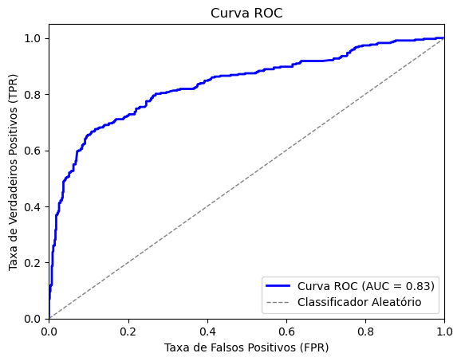

```python
y_pred = SurvFit.predict()
fpr, tpr, thresholds = roc_curve(y, y_pred)
auc = roc_auc_score(y, y_pred)

plt.plot(fpr, tpr, color='blue', lw=2, label=f'Curva ROC (AUC = {auc:.2f})')
plt.plot([0, 1], [0, 1], color='gray', linestyle='--', lw=1, label='Classificador Aleatório')
plt.xlim([0.0, 1.0])
plt.ylim([0.0, 1.05])
plt.xlabel('Taxa de Falsos Positivos (FPR)')
plt.ylabel('Taxa de Verdadeiros Positivos (TPR)')
plt.title('Curva ROC')
plt.legend(loc='lower right')
plt.show()
```

```python
x_test = add_constant(data_test)
y_test_pred = SurvFit.predict(x_test)
rmse = []
for indice, value in enumerate(thresholds):
    y_final_hat = (y_test_pred >= value).astype(int)
    rmse.append(root_mean_squared_error(y_true = gen_sub['Survived'], y_pred = y_final_hat))
print('Limiar: ', thresholds[np.argmin(rmse)])
print('Valor do rmse: ', min(rmse))

y_final_hat = (y_test_pred >= thresholds[np.argmin(rmse)]).astype(int)
```

```
Limiar:  0.5343584858146606
Valor do rmse:  0.20166768818858946
```